# Logistic Regression

Lawson Busch

10/11/2018

```r
library(fivethirtyeight)
library(ggplot2)
library(dplyr)
data(bechdel)
?bechdel
```

# Introduction to the Data

To model binary by year, we can’t use the lm function because binary is categorical.

```r
# bechdel_bin <- bechdel %>%
#   mutate(binary = )
# binary_year <- lm(binary ~ year, data = bechdel)
```

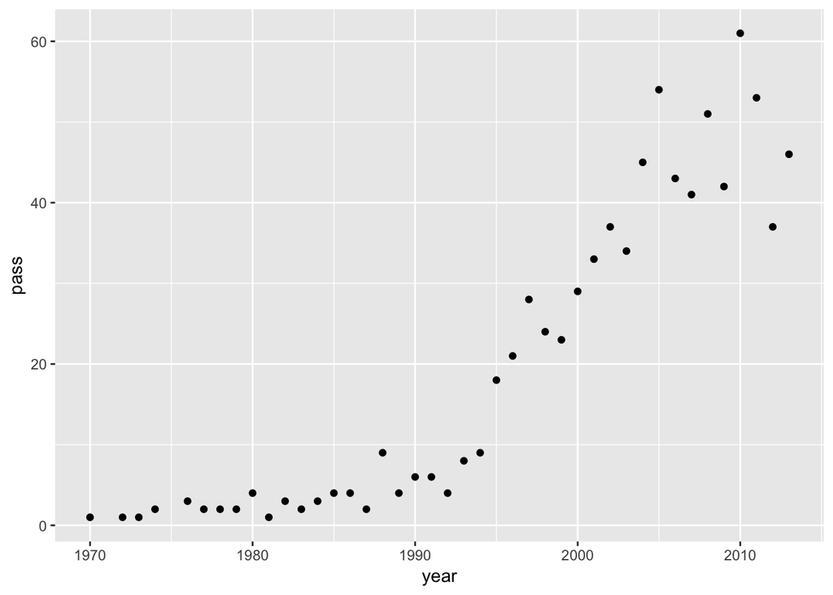

```r
binary_graph <- bechdel %>%
  group_by(year) %>%
  filter(binary == "PASS") %>%
  summarize(pass = n())

ggplot(binary_graph, aes(x = year, y = pass)) + geom_point()
```

# Excercises

## Excercise 1

### 1a)

```r
roll_3_p <- (4/6)
odds_roll_3 = roll_3_p/(1 - roll_3_p)
odds_roll_3
```

```
## [1] 2
```

### 1b)

```r
roll_e = 0.5
odds_roll_e = roll_e/(1-roll_e)
odds_roll_e
```

```
## [1] 1
```

### 1c)

```r
roll_1_2 = 1 - roll_3_p
odds_1_2 = roll_1_2/(1-roll_1_2)
odds_1_2
```

```
## [1] 0.5
```

## Excercise 2

### 2a)

To map a logistic model, we use family = “binomial”.

```r
binary_mod <- glm(factor(binary) ~ year, bechdel, family="binomial")
summary(binary_mod)
```

```
##
## Call:
## glm(formula = factor(binary) ~ year, family = "binomial", data = bechdel)
##
## Deviance Residuals:
##     Min       1Q   Median       3Q      Max
## -1.1787  -1.1179  -0.9527   1.2381   1.5687
##
## Coefficients:
##               Estimate Std. Error z value Pr(>|z|)
## (Intercept) -41.558913  10.916849  -3.807 0.000141 ***
## year          0.020647   0.005451   3.788 0.000152 ***
## ---
## Signif. codes:  0 '***' 0.001 '**' 0.01 '*' 0.05 '.' 0.1 ' ' 1
##
## (Dispersion parameter for binomial family taken to be 1)
##
##     Null deviance: 2467.3  on 1793  degrees of freedom
## Residual deviance: 2452.5  on 1792  degrees of freedom
## AIC: 2456.5
##
## Number of Fisher Scoring iterations: 4
```

### 2b)

$$log(odds) = -41.55+0.02*year$$

### 2c)

The first two equations are equivalent because we simply raise each side to the power of e, removing the natural log. We then equate the second equation to the third by dividing by the odds plus one, giving us the probability.

## Excercise 3)

### 3a)

```r
# Predictions on log(odds) scale
log_pred <- predict(binary_mod, newdata = data.frame(year = bechdel$year))

# Predictions on odds scale (NOTE: exp(2) calculates e^2)
odds_pred <- exp(log_pred)

# Predictions on probability scale
prob_pred <- predict(binary_mod, newdata = data.frame(year = bechdel$year), type = "response")

# Include the 3 sets of predictions in the data
bechdel <- bechdel %>%
    mutate(log_pred = log_pred, odds_pred = odds_pred, prob_pred = prob_pred)
```

### 3b)

```r
bechdel[26,] %>%
    select(log_pred, odds_pred, prob_pred)
```

```
## # A tibble: 1 x 3
##   log_pred odds_pred prob_pred
##      <dbl>     <dbl>     <dbl>
## 1  0.00294      1.00     0.501
```

```r
## # A tibble: 1 x 3
##   log_pred odds_pred prob_pred
##      <dbl>     <dbl>     <dbl>
## 1  0.00294      1.00     0.501
```

### 3c)

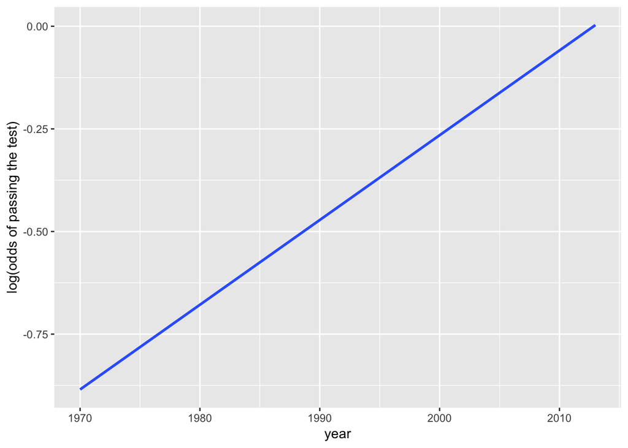

```r
# Plot the log(odds) model
ggplot(bechdel, aes(x=year, y=log_pred)) +
    geom_smooth(se=FALSE) +
    labs(y="log(odds of passing the test)")
```

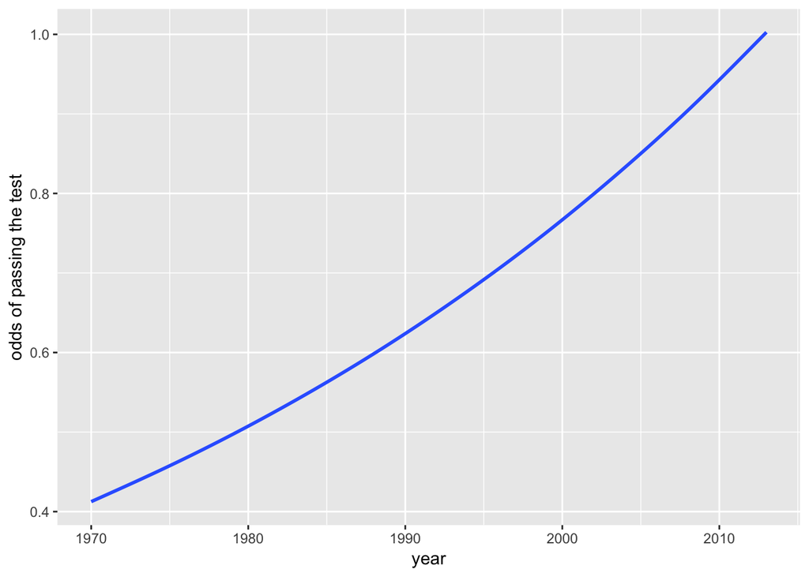

```r
# Plot the odds model
ggplot(bechdel, aes(x=year, y=odds_pred)) +
    geom_smooth(se=FALSE) +
    labs(y="odds of passing the test")
```

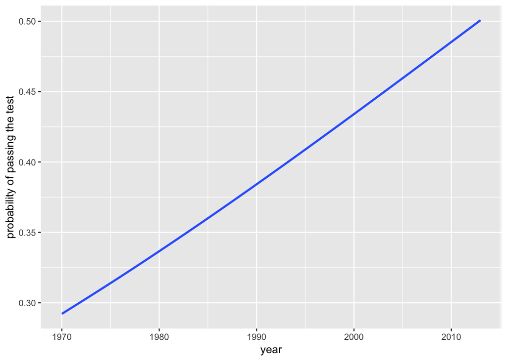

```r
# Plot the probability model
ggplot(bechdel, aes(x=year, y=prob_pred)) +
    geom_smooth(se=FALSE) +
    labs(y="probability of passing the test")
```

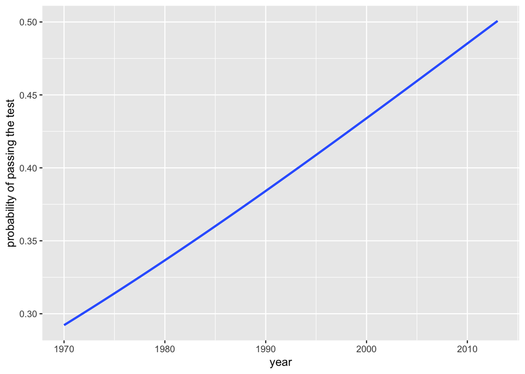

```r
# We could also do this without calculating the predictions first!!
ggplot(bechdel, aes(x=year, y=(as.numeric(as.factor(binary))-1))) +
    geom_smooth(method="glm", method.args=list(family="binomial"), se=FALSE) +
    labs(y="probability of passing the test")
```

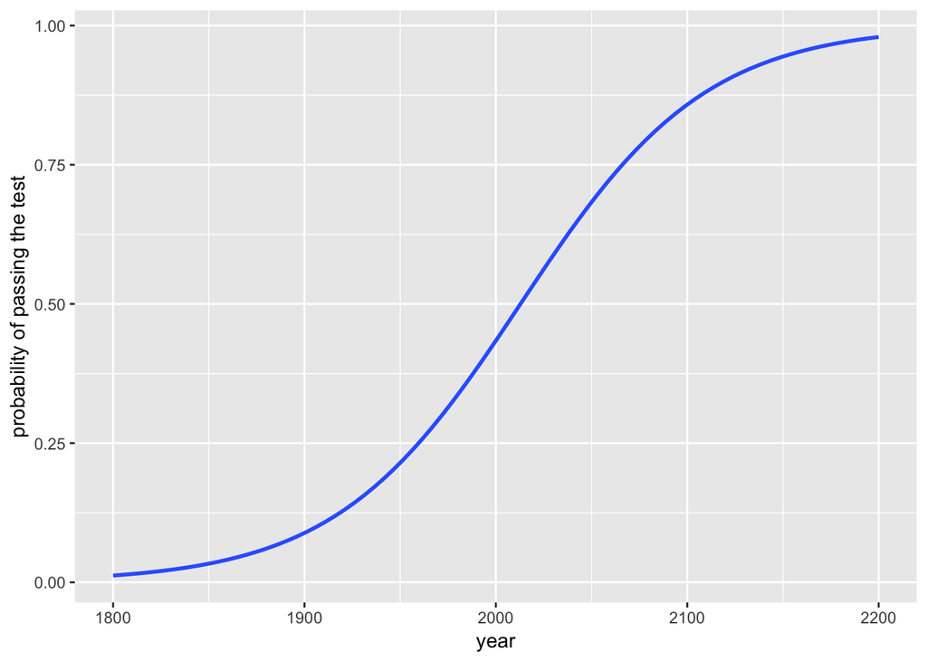

```r
#...and zoom out to see the s shape
ggplot(bechdel, aes(x=year, y=(as.numeric(as.factor(binary))-1))) +
    geom_smooth(method="glm", method.args=list(family="binomial"), se=FALSE, fullrange=TRUE) +
    labs(y="probability of passing the test") +
    lims(x=c(1800,2200))
```

The relationship between binary and year improves as we move forward in time. However, it is not as good as we would inititally expect, as the probability of a moving passing the Bechdel test in 2010 onwards is only 50%, which is lower than I expected. However, it is still an improvement from the initial 30%.

## Excercise 4

### 4a)

```r
interpreted_e = exp(0.020647)
interpreted_e
```

```
## [1] 1.020862
```

From this we can see that the odds of a movie passing the bechdel test in any given year are 1.02 times higher than the odds of the previous year.

### 4b)

```r
log_odds_year <- lm(log_pred ~ year, data = bechdel)
summary(log_odds_year)
```

```
##
## Call:
## lm(formula = log_pred ~ year, data = bechdel)
##
## Residuals:
##        Min         1Q     Median         3Q        Max
## -9.748e-12  1.900e-15  6.600e-15  1.040e-14  2.360e-14
##
## Coefficients:
##               Estimate Std. Error    t value Pr(>|t|)
## (Intercept) -4.156e+01  1.214e-12 -3.424e+13   <2e-16 ***
## year         2.065e-02  6.060e-16  3.407e+13   <2e-16 ***
## ---
## Signif. codes:  0 '***' 0.001 '**' 0.01 '*' 0.05 '.' 0.1 ' ' 1
##
## Residual standard error: 2.304e-13 on 1792 degrees of freedom
## Multiple R-squared:      1,  Adjusted R-squared:      1
## F-statistic: 1.161e+27 on 1 and 1792 DF,  p-value: < 2.2e-16
```

From the P value in the year row, we can conclude that we can reject the null hypothesis that year is not related to the odds of a moving passing the bechdel test.

### 4c)

The intercept does not have any contextual meaning in this case because it is the log odds of a movie released in year 0.

## Excercise 5

```r
bechdel <- bechdel %>%
    mutate(bigbudget=(budget_2013 > median(budget_2013)))
```

### 5a)

```r
bechdel_mod2 <- glm(factor(binary) ~ bigbudget, bechdel, family="binomial")
summary(bechdel_mod2)
```

```
##
## Call:
## glm(formula = factor(binary) ~ bigbudget, family = "binomial",
##     data = bechdel)
##
## Deviance Residuals:
##     Min       1Q   Median       3Q      Max
## -1.2087  -0.9716  -0.9716   1.1464   1.3982
##
## Coefficients:
##               Estimate Std. Error z value Pr(>|z|)
## (Intercept)    0.07328    0.06667   1.099    0.272
## bigbudgetTRUE -0.57874    0.09601  -6.028 1.66e-09 ***
## ---
## Signif. codes:  0 '***' 0.001 '**' 0.01 '*' 0.05 '.' 0.1 ' ' 1
##
## (Dispersion parameter for binomial family taken to be 1)
##
##     Null deviance: 2467.3  on 1793  degrees of freedom
## Residual deviance: 2430.5  on 1792  degrees of freedom
## AIC: 2434.5
##
## Number of Fisher Scoring iterations: 4
```

```r
#Setting bigbudget = true predicts for all values in bigbudget
prob_pred <- predict(bechdel_mod2, newdata = data.frame(bigbudget = TRUE), type = "response")
prob_pred
```

```
##         1
## 0.3762598
```

The probability that a movie with a bigbudget passes the bechdel test is 0.38.

### 5b)

```r
#Setting bigbudget = true predicts for all values in bigbudget
prob_pred <- predict(bechdel_mod2, newdata = data.frame(bigbudget = FALSE), type = "response")
prob_pred
```

```
##        1
## 0.518313
```

The probability that a movie with a small budget passes the bechdel test is 0.51.

## Excercise 6)

### 6a)

On the log scale, we see that a movie moving from a small budget to a big budget decreases its log(odds) by -0.57. The intercept is the odds of a movie with a small budget passing the bechdel test.

```r
interpreted_int = exp(0.07328)
interpreted_int
```

```
## [1] 1.076032
```

```r
interpreted_bud = exp(-0.57874)
interpreted_bud
```

```
## [1] 0.5606043
```

On the odds scale, we see that a movie with a big budget is 0.56 times as likely to pass the bechdel test as a movie with a small budget.

### 6b)

From the p-value on the bigbudget true coefficient, we can conclude that we can reject the null hypothesis that having a big budget does not affect a movies likeliness of passing the bechdel test.